# HIV Self-Testing Study Replication

Author

Trey Chase

Published

January 28, 2026

# 1 Study Overview

## 1.1 Background and Motivation

HIV infection rates remain disproportionately high among minority men who have sex with men (MSM), particularly Black and Latinx individuals. While HIV self-testing offers a promising avenue to increase testing rates and reach populations who might not access traditional testing services, it remains unclear which digital platforms are most effective for promoting HIV self-testing.

Social media sites, dating apps, and information search sites have all been used to reach high-risk populations, but head-to-head comparisons of their relative effectiveness are lacking. Understanding which platforms work best could help public health programs optimize their outreach strategies and budgets.

## 1.2 Study Objectives

### 1.2.1 Primary Objective

To compare the relative effectiveness of three types of web-based platforms—social media sites (Facebook, Instagram), dating apps (Grindr, Jack’D), and information search sites (Google, Bing)—in promoting HIV self-testing among young (18-30 years), minority (Black or Latinx) men who have sex with men. Effectiveness was measured by HIV self-test kit order rates (orders per day) during the promotional campaign period.

### 1.2.2 Secondary Objectives

To evaluate the association between HIV self-test kit ordering and the following psychosocial and behavioral factors:

## 1.3 Study Design

This was a longitudinal observational cohort study conducted in 2020 across two recruitment waves:

- **Wave 1**: Facebook, Grindr, Google (70 days total, including relaunch after Grindr interruption)
- **Wave 2**: Instagram, Jack’D, Bing (38 days)
- **Wave 3**: Twitter, Hornet, Yahoo (excluded from analysis due to COVID-19 impact)

Participants were recruited from 9 high-HIV-incidence areas: District of Columbia, Florida, Georgia, Louisiana, Maryland, Mississippi, Nevada, South Carolina, and Texas.

# 2 Setup and Data Loading

**Load packages and set options**

```r
# Load required packages
library(tidyverse)
library(readxl)
library(gtsummary)
library(emmeans)
library(knitr)
library(kableExtra)

# Set options
options(scipen = 999)  # Disable scientific notation
theme_set(theme_minimal())  # Set ggplot theme
```

**Load and filter data**

```r
# Load data
data <- read_csv("CTN_FINAL.csv", show_col_types = FALSE)

# Filter to per protocol population using PO_FLAG
# According to manuscript: N=254 in final analysis
data_pp <- data %>%
  filter(ENROLLED == "Yes", PO_FLAG == "Include")
```

Initial data contained 271 rows and 478 columns. After filtering to the per protocol population using PO_FLAG, we have **N = 255** participants (manuscript reports N=254).

# 3 Data Preparation

## 3.1 Variable Creation

**Create analysis variables**

```r
data_analysis <- data_pp %>%
  mutate(
    # Convert Q5_3 to character and trim whitespace to preserve multiracial responses
    Q5_3 = str_trim(as.character(Q5_3)),

    # Age (Q3_1)
    age = Q3_1,

    # Ethnicity (Q5_1: 1=Yes Hispanic/Latino, 2=No)
    ethnicity = case_when(
      Q5_1 == 1 ~ "Hispanic/Latinx",
      Q5_1 == 2 ~ "Not Hispanic/Latinx",
      TRUE ~ NA_character_
    ),
    hispanic_latinx = if_else(Q5_1 == 1, 1, 0),

    # Race (Q5_3: 23=White, 24=Black/African American, 25=American Indian,
    #       26=Asian, 27=Pacific Islander, 28=Other)
    # Note: Q5_3 can contain multiple values separated by commas OR concatenated (e.g., "2624")
    # Robust multiracial detection: has comma OR more than 2 digits
    race_primary = case_when(
      str_detect(Q5_3, ",") | nchar(Q5_3) > 2 ~ "Multiracial",
      str_detect(Q5_3, "^25$") ~ "American Indian or Alaskan Native",
      str_detect(Q5_3, "^26$") ~ "Asian",
      str_detect(Q5_3, "^24$") ~ "Black or African American",
      str_detect(Q5_3, "^27$") ~ "Native Hawaiian or Pacific Islander",
      str_detect(Q5_3, "^23$") ~ "White",
      str_detect(Q5_3, "^28$") ~ "Other",
      TRUE ~ NA_character_
    ),

    # Multiracial indicator (has multiple race codes) - robust check for comma OR length > 2
    multiracial = if_else(!is.na(Q5_3) & (str_detect(Q5_3, ",") | nchar(Q5_3) > 2), 1, 0, missing = 0),

    # PrEP history (Q6_2: 1=haven't taken in past 6mo, 2=currently taking, 3=never)
    prep_history = case_when(
      Q6_2 == 3 ~ "Never taken PrEP",
      Q6_2 %in% c(1, 2) ~ "In the past 6 months",
      TRUE ~ NA_character_
    ),
    prep_never = if_else(Q6_2 == 3, 1, 0),
    prep_past6mo = if_else(Q6_2 %in% c(1, 2), 1, 0),

    # Number of male sex partners in past 90 days (Q11_2)
    num_partners = Q11_2,

    # Condom use (Q11_3: 1=Never, 2=Sometimes, 3=About half, 4=Most, 5=Always)
    condom_use = factor(Q11_3,
                       levels = 1:5,
                       labels = c("Never", "Sometimes", "About half the time",
                                 "Most of the time", "Always")),
    condom_use_num = Q11_3,

    # Condomless receptive anal sex (Q11_4: 1=Yes, 2=No)
    condomless_receptive = if_else(Q11_4 == 1, 1, 0),
    condomless_receptive_factor = factor(Q11_4,
                                        levels = 1:2,
                                        labels = c("Yes", "No")),

    # Ever tested for HIV (Q11_5: 1=Yes, 2=No)
    ever_tested_hiv = if_else(Q11_5 == 1, 1, 0),
    ever_tested_factor = factor(Q11_5,
                               levels = 1:2,
                               labels = c("Yes", "No")),

    # Months since last HIV test (filter out 9999 = missing/never tested)
    months_since_test = if_else(LAST_HIV_TEST_MONTHS < 9999,
                               LAST_HIV_TEST_MONTHS,
                               NA_real_),

    # Reasons for not testing (Q11_7, among those who never tested)
    reason_not_tested = factor(Q11_7,
                              levels = 1:8,
                              labels = c("Unlikely to be exposed to HIV",
                                       "Afraid of testing HIV-positive",
                                       "Did not want to think about HIV/HIV-positive",
                                       "Worried about names being reported if positive",
                                       "Dislike for needles",
                                       "Unable to trust that the results will be confidential",
                                       "Unaware of where to get tested",
                                       "Other reasons")),

    # Test kit ordered within 60 days (ORA_WITHIN60_YESNO is "Yes"/"No"/"Missing")
    ordered_kit = if_else(ORA_WITHIN60_YESNO == "Yes", 1, 0),
    ordered_group = if_else(ordered_kit == 1, "Ordered", "Not Ordered")
  )
```

Analysis dataset created with **255 participants**. Of these, **178 (69.8%)** ordered a test kit within 60 days.

# 4 Table 1: Demographic and Behavioral Characteristics

```r
# Calculate all summary statistics
age_med <- median(data_analysis$age, na.rm = TRUE)
age_q25 <- quantile(data_analysis$age, 0.25, na.rm = TRUE)
age_q75 <- quantile(data_analysis$age, 0.75, na.rm = TRUE)

hispanic_n <- sum(data_analysis$Q5_1 == 1, na.rm = TRUE)
hispanic_pct <- round(hispanic_n / nrow(data_analysis) * 100)

# Race counts - Q5_3 is already character in data_analysis
american_indian_n <- sum(str_detect(data_analysis$Q5_3, "25") &
                        !str_detect(data_analysis$Q5_3, ","), na.rm = TRUE)
american_indian_pct <- round(american_indian_n / nrow(data_analysis) * 100, 1)

black_n <- sum(str_detect(data_analysis$Q5_3, "24") &
              !str_detect(data_analysis$Q5_3, ","), na.rm = TRUE)
black_pct <- round(black_n / nrow(data_analysis) * 100, 1)

white_n <- sum(str_detect(data_analysis$Q5_3, "23") &
               !str_detect(data_analysis$Q5_3, ","), na.rm = TRUE)
white_pct <- round(white_n / nrow(data_analysis) * 100, 1)

other_n <- sum(str_detect(data_analysis$Q5_3, "28") &
               !str_detect(data_analysis$Q5_3, ","), na.rm = TRUE)
other_pct <- round(other_n / nrow(data_analysis) * 100, 1)

# Multiracial - people who selected multiple races (has comma)
multiracial_n <- sum(data_analysis$multiracial == 1, na.rm = TRUE)
multiracial_pct <- round(multiracial_n / nrow(data_analysis) * 100, 1)

# PrEP history
never_prep_n <- sum(data_analysis$Q6_2 == 3, na.rm = TRUE)
never_prep_pct <- round(never_prep_n / nrow(data_analysis) * 100, 1)

past6mo_prep_n <- sum(data_analysis$Q6_2 %in% c(1, 2), na.rm = TRUE)
past6mo_prep_pct <- round(past6mo_prep_n / nrow(data_analysis) * 100, 1)

# Number of partners
partners_med <- median(data_analysis$Q11_2, na.rm = TRUE)
partners_q25 <- quantile(data_analysis$Q11_2, 0.25, na.rm = TRUE)
partners_q75 <- quantile(data_analysis$Q11_2, 0.75, na.rm = TRUE)

# Condom use
never_condom_n <- sum(data_analysis$Q11_3 == 1, na.rm = TRUE)
never_condom_pct <- round(never_condom_n / nrow(data_analysis) * 100, 1)

sometimes_condom_n <- sum(data_analysis$Q11_3 == 2, na.rm = TRUE)
sometimes_condom_pct <- round(sometimes_condom_n / nrow(data_analysis) * 100, 1)

half_condom_n <- sum(data_analysis$Q11_3 == 3, na.rm = TRUE)
half_condom_pct <- round(half_condom_n / nrow(data_analysis) * 100, 1)

most_condom_n <- sum(data_analysis$Q11_3 == 4, na.rm = TRUE)
most_condom_pct <- round(most_condom_n / nrow(data_analysis) * 100, 1)

always_condom_n <- sum(data_analysis$Q11_3 == 5, na.rm = TRUE)
always_condom_pct <- round(always_condom_n / nrow(data_analysis) * 100)

# Condomless receptive anal sex
cras_n <- sum(data_analysis$Q11_4 == 1, na.rm = TRUE)
cras_pct <- round(cras_n / nrow(data_analysis) * 100, 1)

# Ever tested
ever_tested_n <- sum(data_analysis$Q11_5 == 1, na.rm = TRUE)
ever_tested_pct <- round(ever_tested_n / nrow(data_analysis) * 100, 1)

# Months since last test (among those tested)
months_data <- data_analysis %>%
  filter(Q11_5 == 1, LAST_HIV_TEST_MONTHS < 9999) %>%
  pull(LAST_HIV_TEST_MONTHS)

months_med <- median(months_data, na.rm = TRUE)
months_q25 <- quantile(months_data, 0.25, na.rm = TRUE)
months_q75 <- quantile(months_data, 0.75, na.rm = TRUE)

# Never tested
never_tested_n <- sum(data_analysis$Q11_5 == 2, na.rm = TRUE)
never_tested_pct <- round(never_tested_n / nrow(data_analysis) * 100, 2)

# Reasons for not testing (among 63 who never tested)
not_tested_data <- data_analysis %>% filter(Q11_5 == 2)

unlikely_n <- sum(not_tested_data$Q11_7 == 1, na.rm = TRUE)
unlikely_pct <- round(unlikely_n / never_tested_n * 100, 1)

afraid_n <- sum(not_tested_data$Q11_7 == 2, na.rm = TRUE)
afraid_pct <- round(afraid_n / never_tested_n * 100, 1)

not_think_n <- sum(not_tested_data$Q11_7 == 3, na.rm = TRUE)
not_think_pct <- round(not_think_n / never_tested_n * 100, 1)

worried_names_n <- sum(not_tested_data$Q11_7 == 4, na.rm = TRUE)
worried_names_pct <- round(worried_names_n / never_tested_n * 100, 1)

needles_n <- sum(not_tested_data$Q11_7 == 5, na.rm = TRUE)
needles_pct <- round(needles_n / never_tested_n * 100)

trust_n <- sum(not_tested_data$Q11_7 == 6, na.rm = TRUE)
trust_pct <- round(trust_n / never_tested_n * 100, 1)

unaware_n <- sum(not_tested_data$Q11_7 == 7, na.rm = TRUE)
unaware_pct <- round(unaware_n / never_tested_n * 100, 1)

other_reason_n <- sum(not_tested_data$Q11_7 == 8, na.rm = TRUE)
other_reason_pct <- round(other_reason_n / never_tested_n * 100, 1)

# Create the table with proper nesting structure
table1_data <- data.frame(
  Characteristic = c(
    "N",
    "Age in years, median (IQR)",
    "Ethnicity, n (%)",
    "   Hispanic/Latinx",
    "Race, n (%)",
    "   American Indian or Alaskan Native",
    "   Black or African American",
    "   White",
    "   Other",
    "   Multiracial",
    "History of PrEP^a^ uptake, n (%)",
    "   Never taken PrEP",
    "   In the past 6 months",
    "Number of male sex partners in the past 90 days, median (IQR)",
    "Condom use, n (%)",
    "   Never",
    "   Sometimes",
    "   About half the time",
    "   Most of the time",
    "   Always",
    "Condomless receptive anal sex in the past 90 days, n (%)",
    "Ever tested for HIV during lifetime, n (%)",
    "If tested for HIV, median (IQR)",
    "   Months since last HIV test",
    "If not tested for HIV, n (%)",
    "Main reasons cited by the 63 participants for not getting tested, n (%)",
    "   Unlikely to be exposed to HIV",
    "   Afraid of testing HIV-positive",
    "   Did not want to think about HIV/HIV-positive",
    "   Worried about names being reported if positive",
    "   Dislike for needles",
    "   Unable to trust that the results will be confidential",
    "   Unaware of where to get tested",
    "   Other reasons"
  ),
  Value = c(
    "254",
    paste0(age_med, " (", age_q25, "-", age_q75, ")"),
    "",
    paste0(hispanic_n, " (", hispanic_pct, ")"),
    "",
    paste0(american_indian_n, " (", american_indian_pct, ")"),
    paste0(black_n, " (", black_pct, ")"),
    paste0(white_n, " (", white_pct, ")"),
    paste0(other_n, " (", other_pct, ")"),
    paste0(multiracial_n, " (", multiracial_pct, ")"),
    "",
    paste0(never_prep_n, " (", never_prep_pct, ")"),
    paste0(past6mo_prep_n, " (", past6mo_prep_pct, ")"),
    paste0(partners_med, " (", partners_q25, "-", partners_q75, ")"),
    "",
    paste0(never_condom_n, " (", never_condom_pct, ")"),
    paste0(sometimes_condom_n, " (", sometimes_condom_pct, ")"),
    paste0(half_condom_n, " (", half_condom_pct, ")"),
    paste0(most_condom_n, " (", most_condom_pct, ")"),
    paste0(always_condom_n, " (", always_condom_pct, ")"),
    paste0(cras_n, " (", cras_pct, ")"),
    paste0(ever_tested_n, " (", ever_tested_pct, ")"),
    "",
    paste0(round(months_med), " (", round(months_q25), "-", round(months_q75), ")"),
    paste0(never_tested_n, " (", never_tested_pct, "%)"),
    "",
    paste0(unlikely_n, " (", unlikely_pct, ")"),
    paste0(afraid_n, " (", afraid_pct, ")"),
    paste0(not_think_n, " (", not_think_pct, ")"),
    paste0(worried_names_n, " (", worried_names_pct, ")"),
    paste0(needles_n, " (", needles_pct, ")"),
    paste0(trust_n, " (", trust_pct, ")"),
    paste0(unaware_n, " (", unaware_pct, ")"),
    paste0(other_reason_n, " (", other_reason_pct, ")")
  )
)

# Display table with proper styling
kable(table1_data,
      col.names = c("Characteristic", "Value"),
      align = c("l", "r")) %>%
  kable_styling(bootstrap_options = c("striped", "hover"), full_width = FALSE) %>%
  row_spec(c(1, 2, 3, 5, 11, 14, 15, 21, 22, 23, 25, 26), bold = TRUE) %>%  # Bold the headers
  add_indent(c(4, 6, 7, 8, 9, 10, 12, 13, 16, 17, 18, 19, 20, 24, 27, 28, 29, 30, 31, 32, 33, 34)) %>%  # Indent subcategories
  add_footnote("^a^PrEP: pre-exposure prophylaxis.", notation = "none")
```

| Characteristic | Value |
| --- | --- |
| N | 254 |
| Age in years, median (IQR) | 25 (21-27) |
| Ethnicity, n (%) |  |
| Hispanic/Latinx | 67 (26) |
| Race, n (%) |  |
| American Indian or Alaskan Native | 5 (2) |
| Black or African American | 207 (81.2) |
| White | 36 (14.1) |
| Other | 15 (5.9) |
| Multiracial | 11 (4.3) |
| History of PrEP^a^ uptake, n (%) |  |
| Never taken PrEP | 233 (91.4) |
| In the past 6 months | 22 (8.6) |
| Number of male sex partners in the past 90 days, median (IQR) | 4 (3-6) |
| Condom use, n (%) |  |
| Never | 37 (14.5) |
| Sometimes | 108 (42.4) |
| About half the time | 37 (14.5) |
| Most of the time | 68 (26.7) |
| Always | 5 (2) |
| Condomless receptive anal sex in the past 90 days, n (%) | 211 (82.7) |
| Ever tested for HIV during lifetime, n (%) | 191 (74.9) |
| If tested for HIV, median (IQR) |  |
| Months since last HIV test | 11 (6-21) |
| If not tested for HIV, n (%) | 64 (25.1%) |
| Main reasons cited by the 63 participants for not getting tested, n (%) |  |
| Unlikely to be exposed to HIV | 8 (12.5) |
| Afraid of testing HIV-positive | 26 (40.6) |
| Did not want to think about HIV/HIV-positive | 9 (14.1) |
| Worried about names being reported if positive | 3 (4.7) |
| Dislike for needles | 5 (8) |
| Unable to trust that the results will be confidential | 3 (4.7) |
| Unaware of where to get tested | 7 (10.9) |
| Other reasons | 3 (4.7) |

^a^PrEP: pre-exposure prophylaxis.

```r
table1_styled <- kable(table1_data,
      col.names = c("Characteristic", "Value"),
      align = c("l", "r")) %>%
  kable_styling(bootstrap_options = c("striped", "hover"), full_width = FALSE) %>%
  row_spec(c(1, 2, 3, 5, 11, 14, 15, 21, 22, 23, 25, 26), bold = TRUE) %>%
  add_indent(c(4, 6, 7, 8, 9, 10, 12, 13, 16, 17, 18, 19, 20, 24, 27, 28, 29, 30, 31, 32, 33, 34)) %>%
  add_footnote("^a^PrEP: pre-exposure prophylaxis.", notation = "none")

# Save as HTML
save_kable(table1_styled, file = "table1.html")
```

# 5 Primary Outcome Analysis

## 5.1 Test Kit Orders by Platform

**Calculate order rates by platform**

```r
# Create platform summary by wave and site
platform_summary <- data_analysis %>%
  group_by(WAVE, SITE, PLATFORM) %>%
  summarise(
    n_orders = sum(ordered_kit, na.rm = TRUE),
    n_participants = n(),
    .groups = "drop"
  ) %>%
  mutate(
    # Add number of days each platform was active
    # From manuscript: Wave 1 = 70 days (combined), Wave 2 = 38 days
    days = case_when(
      WAVE == 1 ~ 70,
      WAVE == 2 ~ 38,
      WAVE == 3 ~ NA_real_,
      WAVE == 4 ~ NA_real_,
      TRUE ~ NA_real_
    ),
    order_rate = n_orders / days
  )

# Display platform summary
platform_summary %>%
  filter(WAVE %in% c(1, 2)) %>%
  arrange(PLATFORM, WAVE) %>%
  kable(digits = 3, caption = "Test Kit Orders by Platform, Wave, and Site") %>%
  kable_styling(bootstrap_options = c("striped", "hover"))
```

Test Kit Orders by Platform, Wave, and Site

| WAVE | SITE | PLATFORM | n_orders | n_participants | days | order_rate |
| --- | --- | --- | --- | --- | --- | --- |
| 1 | Grindr | Dating app | 0 | 2 | 70 | 0.000 |
| 2 | Jack'd | Dating app | 125 | 187 | 38 | 3.289 |
| 1 | Google | Info site | 3 | 3 | 70 | 0.043 |
| 1 | Facebook | Social media | 6 | 7 | 70 | 0.086 |
| 2 | Instagram | Social media | 13 | 15 | 38 | 0.342 |

## 5.2 Platform Type Summary

```r
# Calculate order rates by platform type (Waves 1-2 only)
platform_type_summary <- platform_summary %>%
  filter(WAVE %in% c(1, 2)) %>%
  group_by(PLATFORM) %>%
  summarise(
    total_orders = sum(n_orders),
    total_days = sum(days, na.rm = TRUE),
    .groups = "drop"
  ) %>%
  mutate(order_rate = total_orders / total_days)

platform_type_summary %>%
  kable(digits = 3,
        col.names = c("Platform Type", "Total Orders", "Total Days", "Order Rate (kits/day)")) %>%
  kable_styling(bootstrap_options = c("striped", "hover"))
```

Order Rates by Platform Type (Waves 1-2)

| Platform Type | Total Orders | Total Days | Order Rate (kits/day) |
| --- | --- | --- | --- |
| Dating app | 125 | 108 | 1.157 |
| Info site | 3 | 70 | 0.043 |
| Social media | 19 | 108 | 0.176 |

### 5.2.1 Key Findings

- **Dating apps** had the highest order rate at 1.16 kits/day
- **Social media** had an order rate of 0.18 kits/day
- **Information search sites** had an order rate of 0.04 kits/day

## 5.3 Visualization

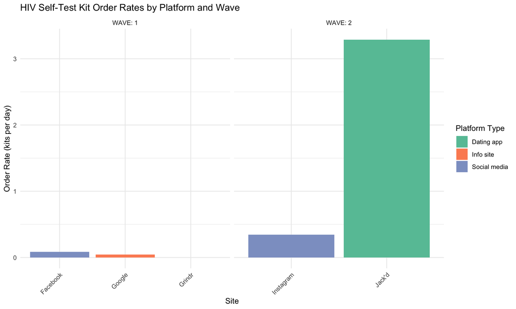

Figure 1: HIV Self-Test Kit Order Rates by Platform and Wave

```r
platform_summary %>%
  filter(WAVE %in% c(1, 2)) %>%
  ggplot(aes(x = SITE, y = order_rate, fill = PLATFORM)) +
  geom_col() +
  facet_wrap(~ WAVE, scales = "free_x", labeller = label_both) +
  labs(
    title = "HIV Self-Test Kit Order Rates by Platform and Wave",
    x = "Site",
    y = "Order Rate (kits per day)",
    fill = "Platform Type"
  ) +
  theme(axis.text.x = element_text(angle = 45, hjust = 1)) +
  scale_fill_brewer(palette = "Set2")
```

# 6 Poisson Regression Models

## 6.1 Wave 1 Comparisons

**Wave 1 Poisson regression**

```r
# Prepare data for Poisson regression (Waves 1-2 only)
poisson_data <- platform_summary %>%
  filter(WAVE %in% c(1, 2)) %>%
  mutate(
    site_wave = paste(SITE, WAVE, sep = "_"),
    log_days = log(days)
  )

# Wave 1 analysis
wave1_data <- poisson_data %>% filter(WAVE == 1)

# Fit Poisson model for Wave 1
wave1_model <- glm(n_orders ~ SITE + offset(log_days),
                   data = wave1_data,
                   family = poisson())

# Display results
summary(wave1_model)
```

```
Call:
glm(formula = n_orders ~ SITE + offset(log_days), family = poisson(),
    data = wave1_data)

Coefficients:
              Estimate Std. Error z value      Pr(>|z|)
(Intercept)    -2.4567     0.4082  -6.018 0.00000000177 ***
SITEGoogle     -0.6931     0.7071  -0.980         0.327
SITEGrindr    -24.0943 42247.1657  -0.001         1.000
---
Signif. codes:  0 '***' 0.001 '**' 0.01 '*' 0.05 '.' 0.1 ' ' 1

(Dispersion parameter for poisson family taken to be 1)

    Null deviance: 8.31776616671934  on 2  degrees of freedom
Residual deviance: 0.00000000041223  on 0  degrees of freedom
AIC: 12.649

Number of Fisher Scoring iterations: 20
```

**Wave 1 Poisson regression**

```r
# Pairwise comparisons with Hochberg adjustment
wave1_emmeans <- emmeans(wave1_model, ~ SITE)
wave1_contrasts <- contrast(wave1_emmeans, method = "pairwise", adjust = "hochberg")

wave1_contrasts
```

```
 contrast          estimate       SE  df z.ratio p.value
 Facebook - Google    0.693     0.71 Inf   0.980  0.9809
 Facebook - Grindr   24.094 42200.00 Inf   0.001  0.9996
 Google - Grindr     23.401 42200.00 Inf   0.001  0.9996

Results are given on the log (not the response) scale.
P value adjustment: hochberg method for 3 tests
```

## 6.2 Wave 2 Comparisons

**Wave 2 Poisson regression**

```r
# Wave 2 analysis
wave2_data <- poisson_data %>% filter(WAVE == 2)

# Fit Poisson model for Wave 2
wave2_model <- glm(n_orders ~ SITE + offset(log_days),
                   data = wave2_data,
                   family = poisson())

# Display results
summary(wave2_model)
```

```
Call:
glm(formula = n_orders ~ SITE + offset(log_days), family = poisson(),
    data = wave2_data)

Coefficients:
            Estimate Std. Error z value            Pr(>|z|)
(Intercept)  -1.0726     0.2774  -3.867             0.00011 ***
SITEJack'd    2.2634     0.2914   7.767 0.00000000000000805 ***
---
Signif. codes:  0 '***' 0.001 '**' 0.01 '*' 0.05 '.' 0.1 ' ' 1

(Dispersion parameter for poisson family taken to be 1)

    Null deviance: 105.1537223507316411997  on 1  degrees of freedom
Residual deviance:   0.0000000000000028866  on 0  degrees of freedom
AIC: 15.083

Number of Fisher Scoring iterations: 3
```

**Wave 2 Poisson regression**

```r
# Pairwise comparisons with Hochberg adjustment
wave2_emmeans <- emmeans(wave2_model, ~ SITE)
wave2_contrasts <- contrast(wave2_emmeans, method = "pairwise", adjust = "hochberg")

wave2_contrasts
```

```
 contrast           estimate    SE  df z.ratio p.value
 Instagram - Jack'd    -2.26 0.291 Inf  -7.767  <.0001

Results are given on the log (not the response) scale.
```

### 6.2.1 Wave 2 Interpretation

# 7 Secondary Outcomes: Psychosocial and Behavioral Factors

```r
# Split by ordering status
ordered <- data_analysis %>% filter(ordered_kit == 1)
not_ordered <- data_analysis %>% filter(ordered_kit == 0)
```

**Sample sizes:**

- Ordered kit: n = 178
- Did not order kit: n = 77

## 7.1 Substance Use (ASSIST)

The Alcohol, Smoking and Substance Involvement Screening Test (ASSIST) was used to assess substance use. Participants were categorized as: None, Problem use (1+ points), or High Risk Substance Use (2+ points based on DSM-5 criteria).

**Substance use analyses**

```r
# ASSIST scoring for substance categories
# Q17_3_1 = Alcohol, Q17_4_1 = Cannabis, Q17_5_1 = Stimulants
# Q17_6_1 = Opioids, Q17_7_1 = Sedatives, Q17_8_1 = Prescribed stimulants

# Create substance use categories (0 = None, 1 = Problem use, 2+ = High risk)
data_analysis <- data_analysis %>%
  mutate(
    alcohol_cat = case_when(
      Q17_3_1 < 1 ~ "None",
      Q17_3_1 == 1 ~ "Problem use",
      Q17_3_1 >= 2 ~ "High Risk Substance Use",
      TRUE ~ NA_character_
    ),
    cannabis_cat = case_when(
      Q17_4_1 < 1 ~ "None",
      Q17_4_1 == 1 ~ "Problem use",
      Q17_4_1 >= 2 ~ "High Risk Substance Use",
      TRUE ~ NA_character_
    ),
    stimulants_cat = case_when(
      Q17_5_1 < 1 ~ "None",
      Q17_5_1 >= 1 ~ "Problem use/High Risk Substance Use",
      TRUE ~ NA_character_
    ),
    opioid_cat = case_when(
      Q17_6_1 < 1 ~ "None",
      Q17_6_1 >= 1 ~ "Problem use/High Risk Substance Use",
      TRUE ~ NA_character_
    ),
    sedative_cat = case_when(
      Q17_7_1 < 1 ~ "None",
      Q17_7_1 >= 1 ~ "Problem use/High Risk Substance Use",
      TRUE ~ NA_character_
    ),
    prescribed_stim_cat = case_when(
      Q17_8_1 < 1 ~ "None",
      Q17_8_1 >= 1 ~ "Problem use/High Risk Substance Use",
      TRUE ~ NA_character_
    )
  )

# Update ordered/not_ordered groups
ordered <- data_analysis %>% filter(ordered_kit == 1)
not_ordered <- data_analysis %>% filter(ordered_kit == 0)

# Alcohol
alcohol_test <- fisher.test(table(data_analysis$alcohol_cat, data_analysis$ordered_kit),
                            simulate.p.value = TRUE)

# Cannabis
cannabis_test <- fisher.test(table(data_analysis$cannabis_cat, data_analysis$ordered_kit),
                             simulate.p.value = TRUE)

# Stimulants
stimulants_test <- fisher.test(table(data_analysis$stimulants_cat, data_analysis$ordered_kit))

# Opioids
opioid_test <- fisher.test(table(data_analysis$opioid_cat, data_analysis$ordered_kit))

# Sedatives
sedative_test <- fisher.test(table(data_analysis$sedative_cat, data_analysis$ordered_kit))

# Prescribed stimulants
prescribed_stim_test <- fisher.test(table(data_analysis$prescribed_stim_cat, data_analysis$ordered_kit))
```

**Substance Use Results:**

- **Alcohol**: p = 0.437
- **Cannabis**: p = 1
- **Stimulants**: p = 0.301
- **Opioids**: p = 0.162
- **Sedatives**: p = 0.633
- **Prescribed stimulants**: p = 0.259

## 7.2 Table: Substance Use by Ordering Status

```r
# Create table with all substance use categories
substance_table <- data_analysis %>%
  select(ordered_group, alcohol_cat, cannabis_cat, stimulants_cat,
         opioid_cat, sedative_cat, prescribed_stim_cat) %>%
  tbl_summary(
    by = ordered_group,
    statistic = all_categorical() ~ "{n} ({p}%)",
    label = list(
      alcohol_cat ~ "Alcohol use",
      cannabis_cat ~ "Cannabis use",
      stimulants_cat ~ "Stimulant use",
      opioid_cat ~ "Opioid use",
      sedative_cat ~ "Sedative use",
      prescribed_stim_cat ~ "Prescribed stimulant use"
    ),
    missing = "no"
  ) %>%
  add_p(test = all_categorical() ~ "fisher.test")

substance_table
```

Substance Use Patterns by HIV Test Kit Ordering Status

| **Characteristic** | **Not Ordered** N = 77<sup>1</sup> | **Ordered** N = 178<sup>1</sup> | **p-value**<sup>2</sup> |
| --- | --- | --- | --- |
| Alcohol use |  |  | 0.4 |
| High Risk Substance Use | 69 (90%) | 156 (88%) |  |
| None | 8 (10%) | 16 (9.0%) |  |
| Problem use | 0 (0%) | 5 (2.8%) |  |
| Cannabis use |  |  | >0.9 |
| High Risk Substance Use | 64 (83%) | 147 (83%) |  |
| None | 12 (16%) | 27 (15%) |  |
| Problem use | 1 (1.3%) | 3 (1.7%) |  |
| Stimulant use |  |  | 0.3 |
| None | 18 (23%) | 31 (18%) |  |
| Problem use/High Risk Substance Use | 59 (77%) | 146 (82%) |  |
| Opioid use |  |  | 0.2 |
| None | 24 (32%) | 41 (23%) |  |
| Problem use/High Risk Substance Use | 52 (68%) | 136 (77%) |  |
| Sedative use |  |  | 0.6 |
| None | 20 (26%) | 41 (23%) |  |
| Problem use/High Risk Substance Use | 57 (74%) | 137 (77%) |  |
| Prescribed stimulant use |  |  | 0.3 |
| None | 21 (27%) | 37 (21%) |  |
| Problem use/High Risk Substance Use | 56 (73%) | 141 (79%) |  |

<sup>1</sup> n (%)  
<sup>2</sup> Fisher’s exact test

## 7.3 Stage of Health Behavior Change

Stage of change for HIV testing readiness (Q12_2):

```r
# Create stage of change variable
# 1 = Precontemplation, 4 = Contemplation, 5 = Determination, 6 = Action, 7 = Maintenance
data_analysis <- data_analysis %>%
  mutate(
    stage_change = factor(Q12_2,
                         levels = c(1, 4, 5, 6, 7),
                         labels = c("Precontemplation", "Contemplation",
                                   "Determination", "Action", "Maintenance"))
  )

# Update groups
ordered <- data_analysis %>% filter(ordered_kit == 1)
not_ordered <- data_analysis %>% filter(ordered_kit == 0)

# Fisher's exact test
stage_test <- fisher.test(table(data_analysis$stage_change, data_analysis$ordered_kit),
                         simulate.p.value = TRUE)
```

**Stage of Change**: p = 0.129

## 7.4 Table: Stage of Change by Ordering Status

```r
stage_change_table <- data_analysis %>%
  select(ordered_group, stage_change) %>%
  tbl_summary(
    by = ordered_group,
    statistic = all_categorical() ~ "{n} ({p}%)",
    label = list(stage_change ~ "Stage of change for HIV testing"),
    missing = "no"
  ) %>%
  add_p(test = all_categorical() ~ "fisher.test")

stage_change_table
```

Stage of Health Behavior Change by HIV Test Kit Ordering Status

| **Characteristic** | **Not Ordered** N = 77<sup>1</sup> | **Ordered** N = 178<sup>1</sup> | **p-value**<sup>2</sup> |
| --- | --- | --- | --- |
| Stage of change for HIV testing |  |  | 0.13 |
| Precontemplation | 8 (10%) | 12 (6.7%) |  |
| Contemplation | 23 (30%) | 35 (20%) |  |
| Determination | 14 (18%) | 27 (15%) |  |
| Action | 19 (25%) | 55 (31%) |  |
| Maintenance | 13 (17%) | 49 (28%) |  |

<sup>1</sup> n (%)  
<sup>2</sup> Fisher’s exact test

## 7.5 Attitudes Toward HIV Testing

Five key attitudes toward HIV testing were assessed:

```r
# Attitudes toward HIV testing (Q15 variables based on appendix)
# These are binary agree/disagree items

# Q15_1: Getting tested for HIV helps people feel better
# Q15_3: Getting tested for HIV helps people from getting HIV
# Q15_4: People in my life would leave if I had HIV
# Q15_5: People who tested positive for HIV should hide it from others
# Q15_6: I would rather not know if I have HIV

data_analysis <- data_analysis %>%
  mutate(
    test_feel_better = factor(Q15_1, levels = 1:2, labels = c("Agree", "Disagree")),
    test_prevent = factor(Q15_3, levels = 1:2, labels = c("Agree", "Disagree")),
    people_leave = factor(Q15_4, levels = 1:2, labels = c("Agree", "Disagree")),
    hide_status = factor(Q15_5, levels = 1:2, labels = c("Agree", "Disagree")),
    rather_not_know = factor(Q15_6, levels = 1:2, labels = c("Agree", "Disagree"))
  )

# Update groups
ordered <- data_analysis %>% filter(ordered_kit == 1)
not_ordered <- data_analysis %>% filter(ordered_kit == 0)

# Fisher's exact tests
test1 <- fisher.test(table(data_analysis$test_feel_better, data_analysis$ordered_kit))
test2 <- fisher.test(table(data_analysis$test_prevent, data_analysis$ordered_kit))
test3 <- fisher.test(table(data_analysis$people_leave, data_analysis$ordered_kit))
test4 <- fisher.test(table(data_analysis$hide_status, data_analysis$ordered_kit))
test5 <- fisher.test(table(data_analysis$rather_not_know, data_analysis$ordered_kit))
```

**Attitudes Toward HIV Testing Results:**

- **Getting tested helps people feel better**: p = 1
- **Getting tested helps prevent HIV**: p = 0.158
- **People would leave if I had HIV**: p = 0.716
- **HIV+ should hide status**: p = 0.049
- **I’d rather not know**: p = 0.825

## 7.6 Table: Attitudes Toward HIV Testing by Ordering Status

```r
testing_attitudes_table <- data_analysis %>%
  select(ordered_group, test_feel_better, test_prevent, people_leave,
         hide_status, rather_not_know) %>%
  tbl_summary(
    by = ordered_group,
    statistic = all_categorical() ~ "{n} ({p}%)",
    label = list(
      test_feel_better ~ "Getting tested for HIV helps people feel better",
      test_prevent ~ "Getting tested for HIV helps prevent HIV",
      people_leave ~ "People in my life would leave if I had HIV",
      hide_status ~ "People who tested positive should hide it",
      rather_not_know ~ "I would rather not know if I have HIV"
    ),
    missing = "no"
  ) %>%
  add_p(test = all_categorical() ~ "fisher.test")

testing_attitudes_table
```

Attitudes Toward HIV Testing by HIV Test Kit Ordering Status

| **Characteristic** | **Not Ordered** N = 77<sup>1</sup> | **Ordered** N = 178<sup>1</sup> | **p-value**<sup>2</sup> |
| --- | --- | --- | --- |
| Getting tested for HIV helps people feel better |  |  | >0.9 |
| Agree | 2 (20%) | 7 (18%) |  |
| Disagree | 8 (80%) | 32 (82%) |  |
| Getting tested for HIV helps prevent HIV |  |  | 0.2 |
| Agree | 70 (91%) | 170 (96%) |  |
| Disagree | 7 (9.1%) | 8 (4.5%) |  |
| People in my life would leave if I had HIV |  |  | 0.7 |
| Agree | 62 (82%) | 149 (84%) |  |
| Disagree | 14 (18%) | 29 (16%) |  |
| People who tested positive should hide it |  |  | 0.049 |
| Agree | 37 (48%) | 60 (34%) |  |
| Disagree | 40 (52%) | 116 (66%) |  |
| I would rather not know if I have HIV |  |  | 0.8 |
| Agree | 9 (12%) | 18 (10%) |  |
| Disagree | 68 (88%) | 160 (90%) |  |

<sup>1</sup> n (%)  
<sup>2</sup> Fisher’s exact test

## 7.7 Attitudes Toward HIV Treatment

```r
# Q13 variables for HIV treatment attitudes (continuous 1-7)
treatment_items <- paste0("Q13_", 1:10)

# Wilcoxon rank sum tests for each item
treatment_tests <- map_dfr(treatment_items, function(var) {
  test <- wilcox.test(data_analysis[[var]] ~ data_analysis$ordered_group)
  tibble(
    item = var,
    p_value = test$p.value
  )
})
```

**Attitudes Toward HIV Treatment Results (Wilcoxon rank sum tests):**

- Q13_1 (Less threatened by HIV+): p = 0.112
- Q13_2 (Less worried about infection): p = 0.276
- Q13_3 (HIV less of a problem): p = 0.013
- Q13_4 (Less serious threat due to treatments): p = 0.103
- Q13_5 (Less concerned about becoming HIV+): p = 0.239
- Q13_6 (Condoms less necessary): p = 0.071
- Q13_7 (HIV+ needs less condom use): p = 0.064
- Q13_8 (Less need for condoms, can start treatments): p = 0.228
- Q13_9 (HIV+ can be cured): p = 0.35
- Q13_10 (Treatments can eradicate virus): p = 0.318

## 7.8 Table: Attitudes Toward HIV Treatment by Ordering Status

```r
# Create labeled treatment attitude variables
treatment_labels <- c(
  "I feel less threatened by HIV+ people now",
  "I am less worried about getting infected",
  "HIV is less of a problem now",
  "HIV is less serious threat due to treatments",
  "I am less concerned about becoming HIV+",
  "Condoms are less necessary now",
  "HIV+ people need condoms less",
  "Less need for condoms, can start treatments",
  "HIV+ can be cured with treatments",
  "Treatments can eradicate the virus"
)

treatment_attitudes_table <- data_analysis %>%
  select(ordered_group, Q13_1:Q13_10) %>%
  tbl_summary(
    by = ordered_group,
    statistic = all_continuous() ~ "{mean} ± {sd}",
    label = setNames(as.list(treatment_labels), paste0("Q13_", 1:10)),
    missing = "no"
  ) %>%
  add_p(test = all_continuous() ~ "wilcox.test")

treatment_attitudes_table
```

| **Characteristic** | **Not Ordered** N = 77<sup>1</sup> | **Ordered** N = 178<sup>1</sup> | **p-value**<sup>2</sup> |
| --- | --- | --- | --- |
| I feel less threatened by HIV+ people now |  |  | 0.14 |
| 1 | 61 (79%) | 125 (70%) |  |
| 2 | 3 (3.9%) | 4 (2.2%) |  |
| 9999 | 13 (17%) | 49 (28%) |  |
| I am less worried about getting infected |  |  | 0.3 |
| 1 | 36 (47%) | 76 (43%) |  |
| 2 | 24 (32%) | 47 (27%) |  |
| 9999 | 16 (21%) | 53 (30%) |  |
| HIV is less of a problem now |  |  | 0.006 |
| 1 | 12 (16%) | 8 (4.5%) |  |
| 2 | 49 (64%) | 117 (66%) |  |
| 9999 | 16 (21%) | 53 (30%) |  |
| HIV is less serious threat due to treatments |  |  | 0.3 |
| 1 | 7 (9.2%) | 10 (5.6%) |  |
| 2 | 53 (70%) | 115 (65%) |  |
| 9999 | 16 (21%) | 53 (30%) |  |
| I am less concerned about becoming HIV+ |  |  | 0.5 |
| 1 | 45 (58%) | 89 (50%) |  |
| 2 | 4 (5.2%) | 12 (6.7%) |  |
| 9999 | 28 (36%) | 77 (43%) |  |
| Condoms are less necessary now |  |  | 0.082 |
| 1 | 33 (43%) | 51 (29%) |  |
| 2 | 12 (16%) | 38 (21%) |  |
| 9999 | 32 (42%) | 89 (50%) |  |
| HIV+ people need condoms less |  |  | 0.030 |
| 1 | 12 (16%) | 10 (5.6%) |  |
| 2 | 33 (43%) | 78 (44%) |  |
| 9999 | 32 (42%) | 89 (50%) |  |
| Less need for condoms, can start treatments |  |  | 0.4 |
| 1 | 8 (10%) | 12 (6.7%) |  |
| 2 | 41 (53%) | 89 (50%) |  |
| 9999 | 28 (36%) | 77 (43%) |  |
| HIV+ can be cured with treatments |  |  | 0.2 |
| 1 | 5 (6.5%) | 11 (6.2%) |  |
| 2 | 3 (3.9%) | 1 (0.6%) |  |
| 9999 | 69 (90%) | 166 (93%) |  |
| Treatments can eradicate the virus |  |  | 0.5 |
| 1 | 3 (3.9%) | 4 (2.2%) |  |
| 2 | 5 (6.5%) | 8 (4.5%) |  |
| 9999 | 69 (90%) | 166 (93%) |  |

<sup>1</sup> n (%)  
<sup>2</sup> Fisher’s exact test; Pearson’s Chi-squared test

## 7.9 HIV-Related Stigma

Four items measuring stigma toward people living with HIV/AIDS (ordinal scale):

```r
# Q14 variables for HIV stigma (ordinal 1-7)
# Wilcoxon rank sum tests

stigma1_test <- wilcox.test(Q14_2 ~ ordered_group, data = data_analysis)  # Afraid of PLWHA
stigma2_test <- wilcox.test(Q14_3 ~ ordered_group, data = data_analysis)  # Could not be friends
stigma3_test <- wilcox.test(Q14_4 ~ ordered_group, data = data_analysis)  # Got what they deserve
stigma4_test <- wilcox.test(Q14_5 ~ ordered_group, data = data_analysis)  # Feel anger
```

**HIV-Related Stigma Results (Wilcoxon rank sum tests):**

- **Afraid of people living with HIV/AIDS**: p = 0.611
- **Could not be friends with someone with HIV/AIDS**: p = 0.037
- **People who get HIV through sex/drugs got what they deserve**: p = 0.381
- **Feel anger toward people with HIV/AIDS**: p = 0.243

## 7.10 Table: HIV-Related Stigma by Ordering Status

```r
hiv_stigma_table <- data_analysis %>%
  select(ordered_group, Q14_2, Q14_3, Q14_4, Q14_5) %>%
  tbl_summary(
    by = ordered_group,
    statistic = all_continuous() ~ "{mean} ± {sd}",
    label = list(
      Q14_2 ~ "I feel afraid of people living with HIV/AIDS",
      Q14_3 ~ "I could not be friends with someone with HIV/AIDS",
      Q14_4 ~ "People who get HIV through sex/drugs got what they deserve",
      Q14_5 ~ "I feel anger toward people with HIV/AIDS"
    ),
    missing = "no"
  ) %>%
  add_p(test = all_continuous() ~ "wilcox.test")

hiv_stigma_table
```

| **Characteristic** | **Not Ordered** N = 77<sup>1</sup> | **Ordered** N = 178<sup>1</sup> | **p-value**<sup>2</sup> |
| --- | --- | --- | --- |
| I feel afraid of people living with HIV/AIDS |  |  | >0.9 |
| 1 | 7 (9.1%) | 12 (6.7%) |  |
| 2 | 2 (2.6%) | 9 (5.1%) |  |
| 3 | 9 (12%) | 21 (12%) |  |
| 4 | 9 (12%) | 20 (11%) |  |
| 5 | 6 (7.8%) | 11 (6.2%) |  |
| 6 | 17 (22%) | 33 (19%) |  |
| 7 | 27 (35%) | 72 (40%) |  |
| I could not be friends with someone with HIV/AIDS |  |  | 0.046 |
| 1 | 4 (5.2%) | 1 (0.6%) |  |
| 2 | 0 (0%) | 1 (0.6%) |  |
| 3 | 1 (1.3%) | 3 (1.7%) |  |
| 4 | 6 (7.8%) | 9 (5.1%) |  |
| 5 | 1 (1.3%) | 7 (3.9%) |  |
| 6 | 19 (25%) | 27 (15%) |  |
| 7 | 46 (60%) | 130 (73%) |  |
| People who get HIV through sex/drugs got what they deserve |  |  | 0.8 |
| 1 | 0 (0%) | 2 (1.1%) |  |
| 2 | 1 (1.3%) | 2 (1.1%) |  |
| 3 | 2 (2.6%) | 4 (2.2%) |  |
| 4 | 7 (9.1%) | 8 (4.5%) |  |
| 5 | 2 (2.6%) | 6 (3.4%) |  |
| 6 | 12 (16%) | 24 (13%) |  |
| 7 | 53 (69%) | 132 (74%) |  |
| I feel anger toward people with HIV/AIDS |  |  | 0.2 |
| 1 | 0 (0%) | 1 (0.6%) |  |
| 4 | 5 (6.5%) | 11 (6.2%) |  |
| 5 | 0 (0%) | 3 (1.7%) |  |
| 6 | 16 (21%) | 20 (11%) |  |
| 7 | 56 (73%) | 143 (80%) |  |

<sup>1</sup> n (%)  
<sup>2</sup> Fisher’s exact test

## 7.11 Medical Mistrust

Seven items measuring trust in healthcare organizations (ordinal scale):

```r
# Q16 variables for medical mistrust (ordinal 1-4)
# Wilcoxon rank sum tests

mistrust_tests <- map_dfr(paste0("Q16_", 1:7), function(var) {
  test <- wilcox.test(data_analysis[[var]] ~ data_analysis$ordered_group)
  tibble(
    item = var,
    p_value = test$p.value
  )
})
```

**Medical Mistrust Results (Wilcoxon rank sum tests):**

- Q16_1 (Better be cautious with healthcare): p = 0.511
- Q16_2 (Patients deceived/misled): p = 0.404
- Q16_3 (Mistakes covered up): p = 0.214
- Q16_4 (Harmful experiments): p = 0.431
- Q16_5 (Don’t keep info private): p = 0.34
- Q16_6 (Wonder if they know what doing): p = 0.912
- Q16_7 (Mistakes are common): p = 0.667

## 7.12 Table: Medical Mistrust by Ordering Status

```r
mistrust_labels <- c(
  "You'd better be cautious when dealing with healthcare organizations",
  "Patients have sometimes been deceived or misled",
  "Healthcare organizations cover up their mistakes",
  "Healthcare organizations have done harmful experiments",
  "Healthcare organizations don't keep information private",
  "Sometimes I wonder if they know what they're doing",
  "Mistakes are common in healthcare organizations"
)

medical_mistrust_table <- data_analysis %>%
  select(ordered_group, Q16_1:Q16_7) %>%
  tbl_summary(
    by = ordered_group,
    statistic = all_continuous() ~ "{mean} ± {sd}",
    label = setNames(as.list(mistrust_labels), paste0("Q16_", 1:7)),
    missing = "no"
  ) %>%
  add_p(test = all_continuous() ~ "wilcox.test")

medical_mistrust_table
```

| **Characteristic** | **Not Ordered** N = 77<sup>1</sup> | **Ordered** N = 178<sup>1</sup> | **p-value**<sup>2</sup> |
| --- | --- | --- | --- |
| You'd better be cautious when dealing with healthcare organizations |  |  | 0.8 |
| 28 | 17 (22%) | 37 (21%) |  |
| 30 | 32 (42%) | 67 (38%) |  |
| 33 | 14 (18%) | 42 (24%) |  |
| 34 | 13 (17%) | 32 (18%) |  |
| Patients have sometimes been deceived or misled |  |  | 0.3 |
| 1 | 11 (14%) | 32 (18%) |  |
| 2 | 34 (44%) | 84 (47%) |  |
| 6 | 22 (29%) | 33 (19%) |  |
| 7 | 10 (13%) | 28 (16%) |  |
| Healthcare organizations cover up their mistakes |  |  | 0.018 |
| 1 | 10 (13%) | 29 (17%) |  |
| 2 | 29 (38%) | 84 (48%) |  |
| 6 | 30 (39%) | 36 (21%) |  |
| 7 | 7 (9.2%) | 26 (15%) |  |
| Healthcare organizations have done harmful experiments |  |  | 0.6 |
| 1 | 14 (18%) | 30 (17%) |  |
| 2 | 25 (32%) | 73 (41%) |  |
| 6 | 26 (34%) | 52 (29%) |  |
| 7 | 12 (16%) | 22 (12%) |  |
| Healthcare organizations don't keep information private |  |  | 0.7 |
| 1 | 11 (14%) | 37 (21%) |  |
| 2 | 29 (38%) | 64 (36%) |  |
| 6 | 23 (30%) | 47 (27%) |  |
| 7 | 13 (17%) | 28 (16%) |  |
| Sometimes I wonder if they know what they're doing |  |  | 0.9 |
| 1 | 9 (12%) | 23 (13%) |  |
| 2 | 28 (36%) | 66 (37%) |  |
| 6 | 30 (39%) | 60 (34%) |  |
| 7 | 10 (13%) | 28 (16%) |  |
| Mistakes are common in healthcare organizations |  |  | >0.9 |
| 1 | 8 (11%) | 21 (12%) |  |
| 2 | 36 (48%) | 89 (50%) |  |
| 6 | 23 (31%) | 47 (27%) |  |
| 7 | 8 (11%) | 20 (11%) |  |

<sup>1</sup> n (%)  
<sup>2</sup> Pearson’s Chi-squared test

# 8 Primary Outcomes: Demographics and Behaviors

## 8.1 Statistical Tests

**Perform comparison tests**

```r
# Age comparison (t-test)
age_test <- t.test(age ~ ordered_group, data = data_analysis)

# Ethnicity (Fisher's exact test)
ethnicity_table <- table(data_analysis$hispanic_latinx, data_analysis$ordered_kit)
ethnicity_test <- fisher.test(ethnicity_table)

# Number of partners (Wilcoxon rank sum test)
partners_test <- wilcox.test(num_partners ~ ordered_group, data = data_analysis)

# Condom use (Chi-square test)
condom_table <- table(data_analysis$condom_use_num, data_analysis$ordered_kit)
condom_test <- chisq.test(condom_table)

# Condomless receptive anal sex (Fisher's exact test)
cras_table <- table(data_analysis$condomless_receptive, data_analysis$ordered_kit)
cras_test <- fisher.test(cras_table)

# Ever tested for HIV (Fisher's exact test)
tested_table <- table(data_analysis$ever_tested_hiv, data_analysis$ordered_kit)
tested_test <- fisher.test(tested_table)
```

**Primary Demographic/Behavioral Test Results:**

- **Age (t-test)**:
  - Ordered: mean = 24.59, SD = 3.61
  - Not ordered: mean = 24.01, SD = 3.73
  - t = -1.145, p = 0.254
- **Ethnicity (Fisher’s exact)**: p = 0.877
- **Number of Partners (Wilcoxon)**:
  - Ordered: median = 3.5
  - Not ordered: median = 4
  - W = 7939, p = 0.042
- **Condom Use (Chi-square)**: χ² = 1.332, p = 0.856
- **Condomless Receptive Anal Sex (Fisher’s exact)**: p = 0.72
- **Ever Tested for HIV (Fisher’s exact)**: p = 0.019

## 8.2 Comprehensive Comparison Table

```r
table_comprehensive <- data_analysis %>%
  select(
    ordered_group,
    age,
    ethnicity,
    race_primary,
    num_partners,
    condom_use,
    condomless_receptive_factor,
    ever_tested_factor
  ) %>%
  tbl_summary(
    by = ordered_group,
    statistic = list(
      all_continuous() ~ "{median} ({p25}-{p75})",
      all_categorical() ~ "{n} ({p}%)"
    ),
    label = list(
      age ~ "Age in years",
      ethnicity ~ "Ethnicity",
      race_primary ~ "Race",
      num_partners ~ "Number of male sex partners",
      condom_use ~ "Condom use",
      condomless_receptive_factor ~ "Condomless receptive anal sex",
      ever_tested_factor ~ "Ever tested for HIV"
    ),
    missing = "no"
  ) %>%
  add_p(
    test = list(
      all_continuous() ~ "wilcox.test",
      all_categorical() ~ "fisher.test"
    )
  )

table_comprehensive
```

Table 1: Characteristics by Test Kit Ordering Status

| **Characteristic** | **Not Ordered** N = 77<sup>1</sup> | **Ordered** N = 178<sup>1</sup> | **p-value**<sup>2</sup> |
| --- | --- | --- | --- |
| Age in years | 24.0 (21.0-27.0) | 25.0 (22.0-28.0) | 0.3 |
| Ethnicity |  |  | 0.9 |
| Hispanic/Latinx | 21 (27%) | 46 (26%) |  |
| Not Hispanic/Latinx | 56 (73%) | 132 (74%) |  |
| Race |  |  | 0.5 |
| American Indian or Alaskan Native | 0 (0%) | 1 (0.6%) |  |
| Black or African American | 64 (83%) | 132 (76%) |  |
| Multiracial | 3 (3.9%) | 8 (4.6%) |  |
| Other | 5 (6.5%) | 9 (5.2%) |  |
| White | 5 (6.5%) | 24 (14%) |  |
| Number of male sex partners | 4.0 (3.0-9.0) | 3.5 (3.0-6.0) | 0.042 |
| Condom use |  |  | 0.8 |
| Never | 13 (17%) | 24 (13%) |  |
| Sometimes | 29 (38%) | 79 (44%) |  |
| About half the time | 12 (16%) | 25 (14%) |  |
| Most of the time | 21 (27%) | 47 (26%) |  |
| Always | 2 (2.6%) | 3 (1.7%) |  |
| Condomless receptive anal sex | 65 (84%) | 146 (82%) | 0.7 |
| Ever tested for HIV | 50 (65%) | 141 (79%) | 0.019 |

<sup>1</sup> Median (Q1-Q3); n (%)  
<sup>2</sup> Wilcoxon rank sum test; Fisher’s exact test

# 9 References

1. Stafylis, C., Vavala, G., Wang, Q., McLeman, B., Lemley, S. M., Young, S. D., Xie, H., Matthews, A. G., Oden, N., Revoredo, L., Shmueli-Blumberg, D., Hichborn, E. G., McKelle, E., Moran, L. M., Jacobs, P., Marsch, L. A., & Klausner, J. D. (2022). Relative Effectiveness of Social Media, Dating Apps, and Information Search Sites in Promoting HIV Self-testing: Observational Cohort Study. *JMIR Formative Research*, 6(9), e35648. https://doi.org/10.2196/35648
2. ClinicalTrials.gov Identifier: NCT04155502. https://clinicaltrials.gov/ct2/show/NCT04155502
3. National Institute on Drug Abuse (NIDA) Clinical Trials Network (CTN) Protocol 0083. https://nida.nih.gov/research-topics/clinical-trials-network
4. Lenth, R. V. (n.d.). Comparisons and contrasts in emmeans. The Comprehensive R Archive Network. Retrieved from https://cran.r-project.org/web/packages/emmeans/vignettes/comparisons.html